# Pre-data Mindset

##### The `Pre-data Mindset` is invaluable when crafting your future analyses. Let’s tell a story about graduate students picking flowers across the country… We’ll focus on **two** characters, **150** flowers, and a few pieces of **never-before-seen** data from their adventures.

##### Dr. Fisher’s *star* grad students `Javier` and `Patrice` were entrusted to collect biological specimens across the country to further the understanding of Species identification. The plan was simple; observe and collect `iris` species from **late-spring to early-fall** in **three regions across the US**.

## Appending Simple Data

##### In our first example we will craft a simplistic dataset. Illustrating a few data points below:

- On a return visit home, `Javier` was struck by the beauty of one particular `iris setosa`. Enough so that he decided to start his research right then and there in the month of `January`.
- `Patrice`, while visiting her friend in `Pennsylvania`, faltered as well. A lovely `iris versicolor` caught her eye while hiking in the Poconos Mountains.

## `wakefield`

> **Authors:** Tyler Rinker  
> **Purpose:** Fast, fake data.  
> **Outlook:** A little awkward to manipulate, but if you need fast, fake data might as well try to make it work.  
> […on github](https://github.com/trinker/wakefield)

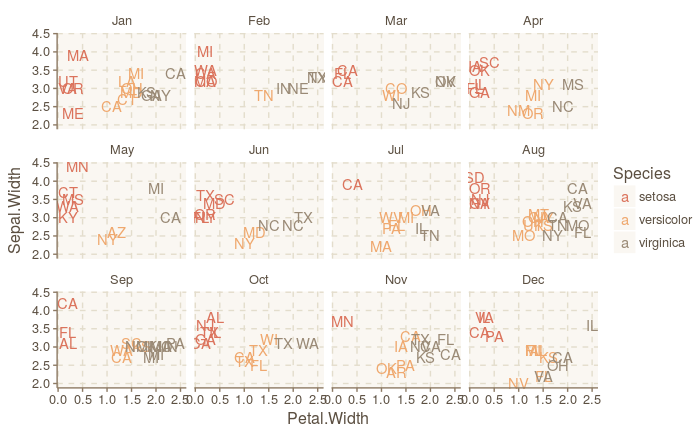

```r
library(wakefield)            ## append basic data
set.seed(55)

## quickly add ID, State, Month to `iris`
extra_iris <- wakefield::r_data_frame(
  n = 150                     ## choose how many you want
  , ID = id
  , State = state(x = datasets::state.abb) ## so-so self-explanatory functions
  , Month = month(x = month.abb)) %>%
  as_data_frame %>%
  cbind(iris)

## example
extra_iris %>% ggplot(aes(Petal.Width, Sepal.Width
                          , color = Species
                          , label = State)) +
  ## print State Abbreviation
  geom_text() +
  ## per Month
  facet_wrap(~Month)
```

```r
## add observedBy
set.seed(77)
extra_iris <- extra_iris %>%
  mutate(observedBy = rep(qc(Javier, Patrice), each = nrow(.)/2)
         , observedBy = sample(observedBy, size = nrow(.), replace =F))
```

##### These flowers were to delightful to not include in their research! In doing so, they have seriously undermined the research methodology. Now that’s a story.

## *Looking for a couple more like this, check out*:

## `charlatan`

> **Authors:** `ropensci`  
> **Purpose:** Dedicated to help quickly create random, fake data.  
> **Outlook:** While the functions are limited at this point. This package has a lot of room for growth and might just end up being the simple solution we all need.  
> […on github](https://github.com/ropensci/charlatan)

```r
# library(charlatan)            # create fake data
# set.seed(33)
#
# ## generate random colors
# charlatan::ch_color_name(n = 5)
#
# [1] "PowderBlue"       "LavenderBlush"    "MediumAquaMarine" "SaddleBrown"
# [5] "DeepSkyBlue"
```

## `generator`

> **Authors:** Paul Hendricks  
> **Purpose:** Generate data containing fake Personally Identifiable Information (PII) in R  
> **Outlook:** Good implementation of PII data types  
> […on github](https://github.com/paulhendricks/generator)

```r
# library(generator)
# set.seed(33)
#
# ## generate full name, latitude, and longitude
# df <- 5 %>% data.frame(
#   fullName = r_full_names(.)
#   , lat = r_latitudes(.)
#   , lon = r_longitudes(.)
# ) %>% walk(print)
#
# [1] 5 5 5 5 5
# [1] Johnetta Collier Lizette Little   Rob Waelchi      Odilia Goodwin   Connie Von
# Levels: Connie Von Johnetta Collier Lizette Little Odilia Goodwin Rob Waelchi
# [1] -30.76168 -64.57607  20.57121 -21.40592  47.76493
# [1]  122.06990   63.75203 -128.81066   26.43362  154.43893
```

## `randNames`

> **Authors:** Karthik Ram  
> **Purpose:** Useful data types, generated randomly.  
> **Outlook:** At its best in the Tidyverse  
> […on github](https://github.com/karthik/randNames)

```r
# library(randNames)           # create fake data
# set.seed(33)
#
# ## generate random names, date of births, cities, and image.paths
# randNames::rand_names(n = 10, nationality = 'US', gender = 'female') %>%
#   select(name.first,name.last, dob, location.city, picture.thumbnail) %>% walk(print)
# # [1] "jeanne"  "jenny"   "allison" "jane"    "brianna" "diane"   "jill"    "sherry"
# #  [9] "dora"    "irene"
# #  [1] "hernandez" "gardner"   "alexander" "burns"     "morgan"    "mills"     "parker"
# #  [8] "nelson"    "morales"   "peck"
# #  [1] "1973-10-04 17:53:23" "1984-09-22 19:38:01" "1959-05-05 02:17:44"
# #  [4] "1981-03-14 23:48:53" "1994-07-30 01:21:41" "1986-01-29 11:40:39"
# #  [7] "1979-03-12 11:23:57" "1982-04-07 08:18:12" "1979-07-28 20:02:21"
# # [10] "1972-11-27 22:14:11"
# #  [1] "el paso"         "odessa"          "north las vegas" "torrance"
# #  [5] "chesapeake"      "irving"          "elgin"           "broken arrow"
# #  [9] "chattanooga"     "nampa"
# #  [1] "https://randomuser.me/api/portraits/thumb/women/10.jpg"
# #  [2] "https://randomuser.me/api/portraits/thumb/women/91.jpg"
# #  [3] "https://randomuser.me/api/portraits/thumb/women/7.jpg"
# #  [4] "https://randomuser.me/api/portraits/thumb/women/90.jpg"
# #  [5] "https://randomuser.me/api/portraits/thumb/women/15.jpg"
# #  [6] "https://randomuser.me/api/portraits/thumb/women/50.jpg"
# #  [7] "https://randomuser.me/api/portraits/thumb/women/74.jpg"
# #  [8] "https://randomuser.me/api/portraits/thumb/women/69.jpg"
# #  [9] "https://randomuser.me/api/portraits/thumb/women/6.jpg"
# # [10] "https://randomuser.me/api/portraits/thumb/women/83.jpg"
```

# Appending Not-So-Simple Data

##### In our second example we will craft a simple dataset using complex methods. Illustrating a few items below:

- *Only* `iris virginica` was observed in `Mar` & `Apr`
- No specimens were observed outside the `Mar` - `Sep` timeframe

## `foreach`

> **Authors:** Rich Calaway  
> **Purpose:** For loops, for real.  
> **Outlook:** Big implications, but difficult to grasp with added complexity.  
> […on github](https://github.com/cran/foreach)

```r
library(foreach)              # for loops
library(wrapr)                # helpful quoting

set.seed(6)

## function to generate probabilities based on list length
get_probs <- function(j){
  set <- sample(1:20, j, replace =T)
  probs <- map(set, ~.x/sum(set))
  probs
}

# ls <- c(2, 3, 4)
# (map(ls, get_probs))

## use get_probs to sample one element from lists
get_element <- function(ls){
  len <- length(ls)
  sample(ls, 1, prob = get_probs(len))
}

# arch <- qc(Loos, Corbusier, Neutra)
# (df <- foreach(1:8, .combine = rbind) %do% get_element(arch))

set.seed(1)

## collections
region <- qc(midwest, northwest, southeast)
season <- qc(early.summer, summer, early.fall)
palette <- qc(cm.colors, heat.colors, all)

extras <- list(region, season, palette)

## create a reference
species_criteria <- foreach(qc(setosa, virginica, versicolor), .combine = cbind) %do%
  map(extras, get_element) %>%
  as.tibble

## organize the information
colnames(species_criteria) <- qc(setosa, virginica, versicolor)
rownames(species_criteria) <- qc(region, season, palette)

glimpse(species_criteria)
```

```
Observations: 3
Variables: 3
$ setosa     <list> ["midwest", "summer", "cm.colors"]
$ virginica  <list> ["midwest", "early.summer", "cm.colors"]
$ versicolor <list> ["northwest", "early.fall", "cm.colors"]
```

```r
## lists to supply data

## states by region
states <- list(midwest = qc(MI, OH, IN, KY)
               , northwest = qc(CA, OR, ID, WA, MT)
               , southeast = qc(FL))

## months by season
months <- list(early.summer = qc(Mar, Apr, May, Jun)
               , summer = qc(May, Jun, Jul)
               , early.fall = qc(Aug, Sep))

## helper levels
month_levels <- c(
  "Jan", "Feb", "Mar", "Apr", "May", "Jun",
  "Jul", "Aug", "Sep", "Oct", "Nov", "Dec"
)

## colors by palette
colors <- list(cm.colors = cm.colors(6)
               , heat.colors = heat.colors(3)
               , all = rainbow(20))
```

```r
## get varying results by Species
get_data <- function(Species){
  store <- species_criteria[Species]

  ## get_state
  pos_states = states[unlist(store[1,1])]
  State <- get_element(unlist(pos_states))

  ## get_month
  pos_month = months[unlist(store[2,1])]
  Month <- get_element(unlist(pos_month))

  ## get_color
  pos_color = colors[unlist(store[3,1])]
  Color <- get_element(unlist(pos_color))

  append <- tibble(State=State, Month=Month, Color=Color)
  append
}
```

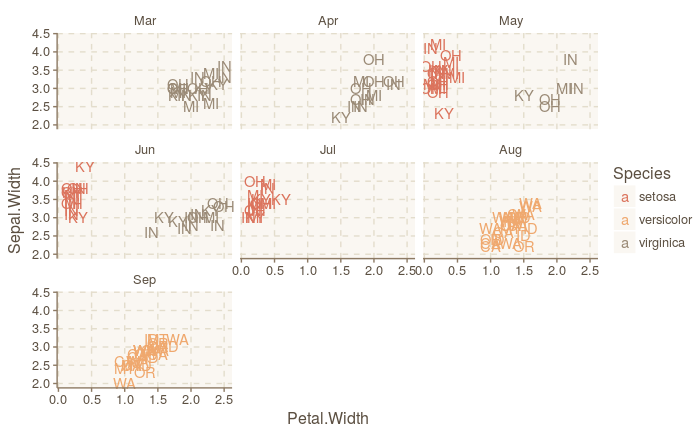

```r
looped_iris <- iris %>% foreach(1:n, .combine = cbind) %do%
  map(as.character(iris$Species), get_data) %>%
  cbind(iris) %>%
  dplyr::select(-result.2) %>%
  unnest() %>%
  mutate(Month = factor(Month, levels = month_levels))

## example
looped_iris %>% ggplot(aes(Petal.Width, Sepal.Width
                          , color = Species
                          , label = State)) +
  ## print State Abbreviation
  geom_text() +
  ## per Month
  facet_wrap(~Month)
```

# A Simplified, Complex Append

##### In our third example we will craft a simple dataset using complex methods. Illustrating the item below:

- The items from the second example are still true
- A relationship exists between flower color and region

## `fabricatr` | `randomizr` | `estimatr`

> **Authors:** `DeclareDesign`  
> **Purpose:** Tools for Research Design  
> **Outlook:** For a real Research Design practitioner.  
> […on github](https://github.com/DeclareDesign/fabricatr)

```r
# install.packages("fabricatr", dependencies = TRUE,
#                  repos = c("http://r.declaredesign.org", "https://cloud.r-project.org"))
library(fabricatr)

## joined data
as.data.frame(t(species_criteria)) %>%
  rownames_to_column(var = 'Species') %>%
  right_join(., iris) %>%
  mutate(region = as.factor(unlist(region))
         , season = as.factor(unlist(season))
         , palette = as.factor(unlist(palette))) -> criteria_iris

set.seed(44)

## get a normally distributed categorical variable based on defined group
fab_iris <- fabricate(
  data = criteria_iris
    , group_id = criteria_iris$region
    , color = draw_normal_icc(mean = 0, N = N, clusters = group_id, ICC = 0.9)
    ) %>% filter(!is.na(color))

## attach meaningful label
fab_iris <- fabricate(
  data = fab_iris
  , color_label = draw_ordered(
    x = color
    , breaks = c(-Inf, -4, -2, 0, 2, 4, Inf)
    , break_labels = colors$cm.colors
  )
)
```

```r
library(skimr)
skim(fab_iris %>% dplyr::select(region, color) %>% group_by(region))
```

```
Skim summary statistics
 n obs: 150
 n variables: 2
 group variables: region

Variable type: numeric
    region variable missing complete   n  mean   sd    p0   p25 median  p75 p100     hist
   midwest    color       0      100 100  1.96 1.06 -0.67  1.29   1.8  2.68 4.99 ▁▂▆▇▃▃▂▁
 northwest    color       0       50  50 -0.13 1.18 -3.17 -0.71  -0.14 0.68 2.71 ▁▂▃▇▇▇▂▁
```

```r
# skim(fab_iris %>% dplyr::select(Species, region, color) %>% group_by(region, Species))
```

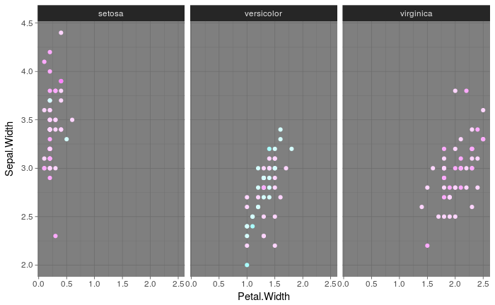

```r
## example
fab_iris %>% ggplot(aes(Petal.Width, Sepal.Width
                        , color = color_label)) +
  geom_point() +
  scale_color_identity() +
  ## per Species
  facet_grid(~Species) +
  theme_dark()
```

## Let’s Take This Version of `iris` Through a Data Science Routine

#### Use Case: K-means Clusters

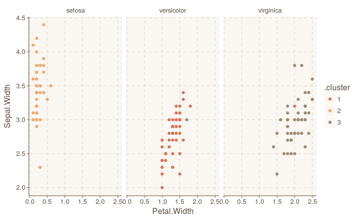

```r
## get clusters using kmeans
## we know are expecting 3 Species
set.seed(88)

## create model
kclust <- fab_iris %>%
  dplyr::select(Petal.Width, Petal.Length
                , Sepal.Width, Sepal.Length
                , color) %>%
  kmeans(centers=3, nstart=10)

## create dataframe with factors; use broom
library(broom)                #working with model data
iris_kclust <- augment(kclust, iris)

## plot
ggplot(iris_kclust, aes(x=Petal.Width, y=Sepal.Width
                        , color=.cluster)) +
  geom_point() +
  facet_wrap(~Species)
```

## Benchmark Tables

### Missed Classifications

```
            .cluster
Species      1 2 3
  setosa     0 0 0
  versicolor 0 0 4
  virginica  1 0 0
```

### Percantage of Missed Classifications

```
     Species miss n perc
1 versicolor    1 4   8%
2  virginica    1 1   2%
```